# Project -5 Modelling Compressive Strength of Concrete using Regression

### (5.3) Outlier Detection

```python
vote_df = pd.DataFrame()
data_without_target = df.drop(target_var,axis=1)
rounds = 5
for i in tqdm(range(0,rounds)):
    clf = IsolationForest(behaviour='new', max_samples='auto',
                          random_state=123, contamination='auto')
#     print(clf)
    clf.fit(data_without_target)
    pred_train = clf.predict(data_without_target)
    vote_df[f'score_{i}'] = pred_train
    vote_df[f'score_{i}'] = vote_df[f'score_{i}'].apply(lambda x : 0 if x == -1 else x)
vote_df['vote'] = vote_df.sum(axis=1)
outliers = df[vote_df['vote'] != rounds]
inliers = df[~df.index.isin(outliers.index)]
display(f"Outlier(%): {(len(outliers)*100)/len(df):.2f}%")
```

```
'Outlier(%): 22.23%'
```

Outlier Analysis

`CEMENT` </br>

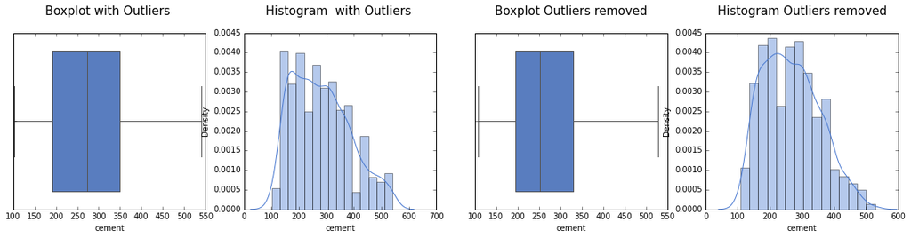

`SLAG` </br>

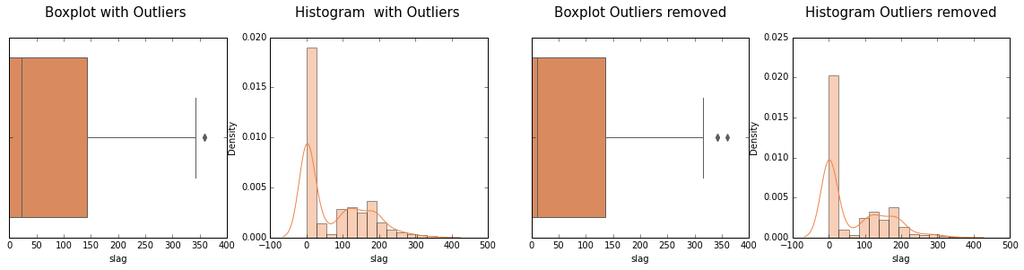

`ASH` </br>

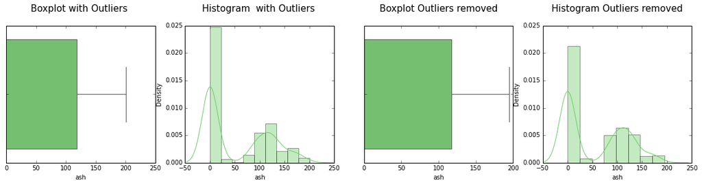

`WATER` </br>

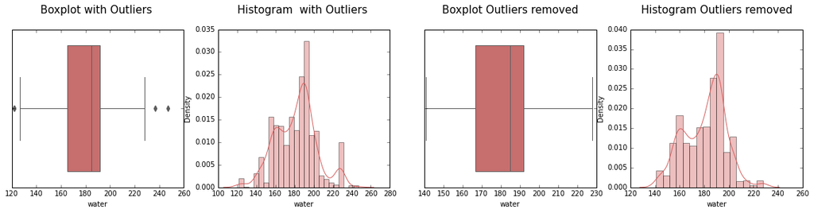

`SUPERPLASTIC` </br>

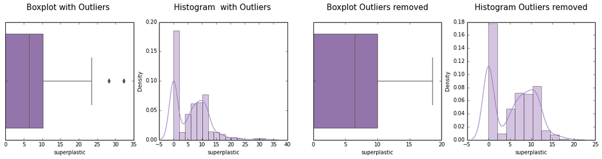

`COARSEAGG` </br>

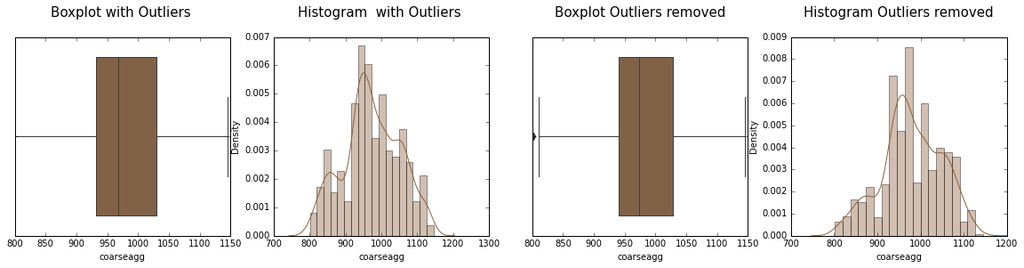

`FINEAGG` </br>

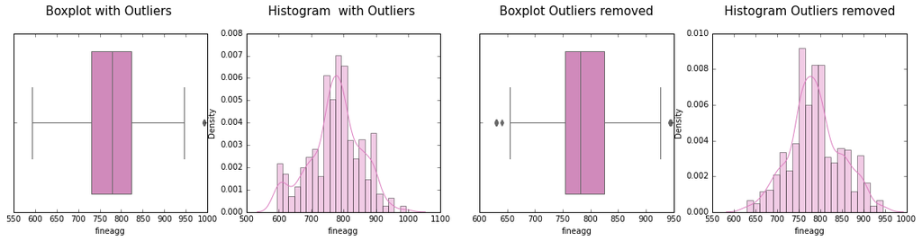

`AGE` </br>

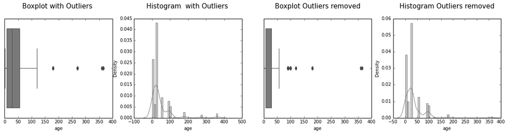

`STRENGTH` </br>

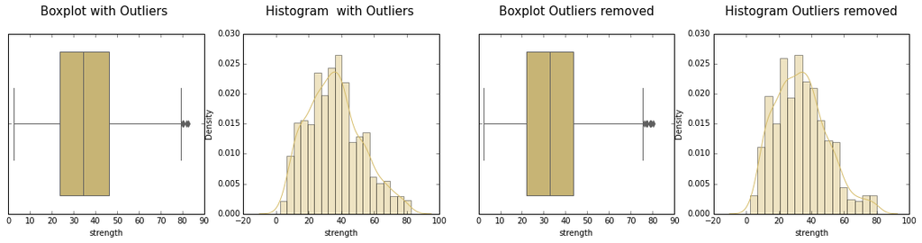

```python
sncp_c1 = sns.color_palette("muted", 40)

num_cols=4

display(Markdown("# <center><u>Outlier Analysis</u></center>\n\n"))
for color,index in enumerate((range(0,len(cont_var_list)))):
    fig, ax = plt.subplots(1,num_cols,figsize=(20,4))

    display(Markdown(f"## <center>`{cont_var_list[index].upper()}`</center></br>"))

    sns.boxplot(df[cont_var_list[index]],color=sncp_c1[color],ax=ax[0]);
    ax[0].set_title(f'Boxplot with Outliers \n',{'fontsize':15})

    sns.distplot(df[cont_var_list[index]],kde=True,color=sncp_c1[color],ax=ax[1]);
    ax[1].set_title(f'Histogram  with Outliers \n',{'fontsize':15})

    sns.boxplot(inliers[cont_var_list[index]],color=sncp_c1[color],ax=ax[2]);
    ax[2].set_title(f'Boxplot Outliers removed\n',{'fontsize':15})

    sns.distplot(inliers[cont_var_list[index]],color=sncp_c1[color],ax=ax[3]);
    ax[3].set_title(f'Histogram Outliers removed\n',{'fontsize':15})
    plt.show()
```

### (5.4) Low Variance Variables.

Variance Threshold

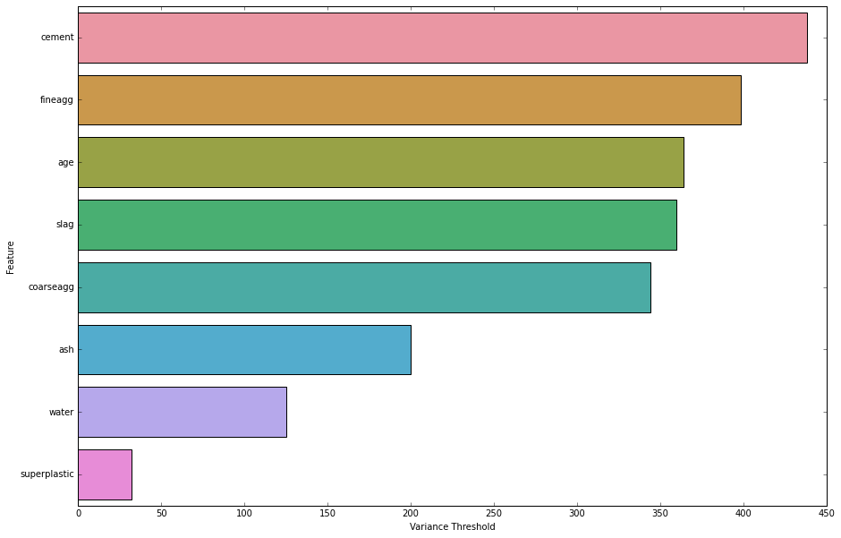

```python
# Check the Variance Threshold
%run edafunc.py
show_variance_threshold(df,target_var)
```

#### Observation:

1. There are no IV with `zero` variance. Hence, we need not eliminate those IVs with zero variance.
2. However, `superplastic` has the least variance in the data. Need further analysis

### (5.5) MultiCollinearity

```python
%run edafunc.py
orig_vif_df = get_VIF_Table(df[columns_to_show])
display(Markdown("#### <u> Initial VIF Table</u>"),orig_vif_df)

display(Markdown("#### <u> Final VIF Table</u>"))
display(remove_multicollinearity(df,target_var,ret_vif_table=True))
```

Initial VIF Table

|  | feature | VIF |
| --- | --- | --- |
| 0 | cement | 15.456717 |
| 1 | slag | 3.329127 |
| 2 | ash | 4.147833 |
| 3 | water | 82.157569 |
| 4 | superplastic | 5.471094 |
| 5 | coarseagg | 84.955779 |
| 6 | fineagg | 72.790995 |
| 7 | age | 1.699459 |

Final VIF Table

|  | feature | VIF |
| --- | --- | --- |
| 0 | cement | 2.819482 |
| 1 | slag | 1.526264 |
| 2 | ash | 1.879115 |
| 3 | superplastic | 2.921784 |
| 4 | age | 1.550374 |

#### Observations:

1. As we observe the data has multi collinearity and the same needs to be handled while modelling.
2. `coarseagg`, `water` , `finegg` , `cement` and `superplastic`have VIFs higher than the acceptable limits of 5.
3. We also observe that variables, `ash`, `slag` and `age` have much lower VIF.
4. WE expect that, eliminating `coarseagg` or`water` or `fineagg` or a combination of these would bring down the VIF below 5. But we cannot eliminate any of these variables as they are essential to the compressive strength of the concrete.

## (6) Feature Engineering

#### (6.1) Declaring global variables

```python
target_var = 'strength'
random_state = 777
score_board = pd.DataFrame(columns=['Test','R2-Mean','R2-Std','Features'])
model_score_board = pd.DataFrame(columns=['Test','Score-Test','Score-Std','Score-Validation','Features'])
```

#### (6.2) Generating a baseline score from ExtraTrees Regressor to score feature engineering

```python
%run edafunc.py
mpl1 = make_pipeline(RobustScaler(),PowerTransformer())
df_pipe1 = pd.DataFrame(data=mpl1.fit_transform(df.drop(target_var,axis=1)),columns=df.drop(target_var,axis=1).columns)
X_pre_feat = df_pipe1.values
y_pre_feat = df[target_var].values
score_pre_feat = basemodel_score(X_pre_feat,y_pre_feat)
score_board = score_board.append({'Test':'Baseline Score',
                                  'R2-Mean':score_pre_feat[0],
                                 'R2-Std':score_pre_feat[1],
                                 'Features':df_pipe1.columns },ignore_index=True)
score_board
```

|  | Test | R2-Mean | R2-Std | Features |
| --- | --- | --- | --- | --- |
| 0 | Baseline Score | 0.912 | 0.0397 | Index(['cement', 'slag', 'ash', 'water', 'superplastic', 'coarseagg', 'fineagg', 'age'], dtype='object') |

#### (6.3) Creating additional columns.

```
1. This is based on the domain knowledge that concrete is a complex mixture or ratios of chemical compounds. Hence, creating additional features as ratios.
```

```python
df_feat = df.copy()

df_feat['water/cement'] = df_feat['water'] / df_feat['cement']
# df_feat['superplastic/cement'] = df_feat['superplastic'] / df_feat['cement']
df_feat['ash/cement'] = df_feat['ash'] / df_feat['cement']
df_feat['slag/cement'] = df_feat['slag'] / df_feat['cement']
df_feat['cement/fineagg'] = df_feat['fineagg']/df_feat['cement']
df_feat['cement/coarseagg'] = df_feat['coarseagg']/df_feat['cement']
df_feat['superplastic/water'] = df_feat['superplastic']/df_feat['water']
df_feat.head()
```

|  | cement | slag | ash | water | superplastic | coarseagg | fineagg | age | strength | water/cement | ash/cement | slag/cement | cement/fineagg | cement/coarseagg | superplastic/water |
| --- | --- | --- | --- | --- | --- | --- | --- | --- | --- | --- | --- | --- | --- | --- | --- |
| 0 | 141.3 | 212.0 | 0.0 | 203.5 | 0.0 | 971.8 | 748.5 | 28 | 29.89 | 1.440198 | 0.000000 | 1.500354 | 5.297240 | 6.877565 | 0.000000 |
| 1 | 168.9 | 42.2 | 124.3 | 158.3 | 10.8 | 1080.8 | 796.2 | 14 | 23.51 | 0.937241 | 0.735938 | 0.249852 | 4.714032 | 6.399053 | 0.068225 |
| 2 | 250.0 | 0.0 | 95.7 | 187.4 | 5.5 | 956.9 | 861.2 | 28 | 29.22 | 0.749600 | 0.382800 | 0.000000 | 3.444800 | 3.827600 | 0.029349 |
| 3 | 266.0 | 114.0 | 0.0 | 228.0 | 0.0 | 932.0 | 670.0 | 28 | 45.85 | 0.857143 | 0.000000 | 0.428571 | 2.518797 | 3.503759 | 0.000000 |
| 4 | 154.8 | 183.4 | 0.0 | 193.3 | 9.1 | 1047.4 | 696.7 | 28 | 18.29 | 1.248708 | 0.000000 | 1.184755 | 4.500646 | 6.766150 | 0.047077 |

```python
cols_to_drop = ['cement','superplastic','fineagg','coarseagg','ash','slag','water']
df_feat.drop(cols_to_drop,axis=1,inplace=True)
df_feat.sample(10)
```

|  | age | strength | water/cement | ash/cement | slag/cement | cement/fineagg | cement/coarseagg | superplastic/water |
| --- | --- | --- | --- | --- | --- | --- | --- | --- |
| 364 | 90 | 54.32 | 0.400000 | 0.000000 | 0.000000 | 1.483750 | 1.950417 | 0.000000 |
| 446 | 100 | 55.02 | 1.061212 | 0.800606 | 0.778788 | 4.524848 | 6.095758 | 0.046259 |
| 623 | 270 | 53.30 | 0.600000 | 0.000000 | 0.000000 | 1.763158 | 2.452632 | 0.000000 |
| 972 | 3 | 14.94 | 1.048387 | 0.768220 | 0.775986 | 4.459976 | 6.011350 | 0.044444 |
| 1003 | 56 | 80.20 | 0.567810 | 0.000000 | 0.873648 | 2.038616 | 2.912264 | 0.056039 |
| 1025 | 28 | 13.29 | 1.333333 | 1.229630 | 0.000000 | 5.962963 | 7.118519 | 0.055556 |
| 658 | 28 | 55.94 | 0.360000 | 0.000000 | 0.000000 | 1.167619 | 2.142857 | 0.000000 |
| 333 | 28 | 19.69 | 0.734127 | 0.000000 | 0.000000 | 3.111111 | 4.408730 | 0.000000 |
| 86 | 28 | 67.57 | 0.280000 | 0.000000 | 0.000000 | 1.706000 | 1.932000 | 0.028571 |
| 401 | 90 | 39.36 | 1.375358 | 0.000000 | 1.500000 | 5.780086 | 7.500000 | 0.000000 |

```python
mpl = make_pipeline(RobustScaler(),PowerTransformer())
df_temp = pd.DataFrame(data=mpl.fit_transform(df_feat.drop(target_var,axis=1)),columns=df_feat.drop(target_var,axis=1).columns)
X_feat = df_temp.values
y_feat = df_feat[target_var].values
print(X_feat.shape,y_feat.shape)
```

```
(1030, 7) (1030,)
```

```python
# Vderify Pre-processing
df_temp.describe().T
```

|  | count | mean | std | min | 25% | 50% | 75% | max |
| --- | --- | --- | --- | --- | --- | --- | --- | --- |
| age | 1030.0 | -2.069542e-17 | 1.000486 | -1.656866 | -1.162898 | 0.055192 | 0.827696 | 2.178271 |
| water/cement | 1030.0 | 2.759389e-17 | 1.000486 | -2.164088 | -0.645721 | -0.035396 | 0.764427 | 2.417749 |
| ash/cement | 1030.0 | -1.310710e-16 | 1.000486 | -0.870879 | -0.870879 | -0.870879 | 1.041458 | 1.709425 |
| slag/cement | 1030.0 | -8.278168e-17 | 1.000486 | -0.944724 | -0.944724 | -0.566374 | 0.936624 | 1.653009 |
| cement/fineagg | 1030.0 | 2.414466e-17 | 1.000486 | -2.093522 | -0.746742 | -0.044144 | 0.845495 | 2.791325 |
| cement/coarseagg | 1030.0 | 2.069542e-17 | 1.000486 | -2.006476 | -0.800622 | -0.084533 | 0.832981 | 2.203591 |
| superplastic/water | 1030.0 | 1.034771e-17 | 1.000486 | -1.149450 | -1.149450 | 0.171179 | 0.788710 | 2.766247 |

```python
# Running the base model again to score feature engineering.
%run edafunc.py
score_feat = basemodel_score(X_feat,y_feat)
score_board = score_board.append({'Test':'Post Feature Engineering',
                                  'R2-Mean':score_feat[0],
                                 'R2-Std':score_feat[1],
                                 'Features':df_temp.columns },ignore_index=True)
score_board
```

|  | Test | R2-Mean | R2-Std | Features |
| --- | --- | --- | --- | --- |
| 0 | Baseline Score | 0.9120 | 0.0397 | Index(['cement', 'slag', 'ash', 'water', 'superplastic', 'coarseagg', 'fineagg', 'age'], dtype='object') |
| 1 | Post Feature Engineering | 0.9093 | 0.0375 | Index(['age', 'water/cement', 'ash/cement', 'slag/cement', 'cement/fineagg', 'cement/coarseagg', 'superplastic/water'], dtype='object') |

#### Observations:

1. There is a small dip in the R2 but witrh 7 variables instead of the initial 8.

#### (6.4) Correlation based Cluster Analysis

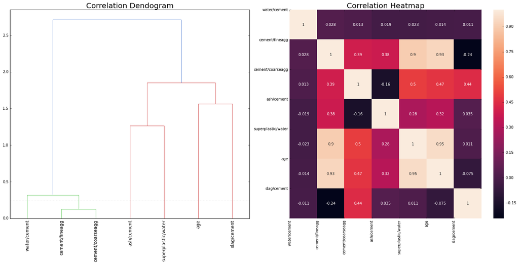

```python
from scipy.stats import spearmanr
from scipy.cluster import hierarchy
from collections import defaultdict

cluster_height = 0.25

fig, (ax1,ax2) = plt.subplots(1,2,figsize=(20, 10))

corr = spearmanr(X_feat).correlation
corr_linkage = hierarchy.ward(corr)
dendro = hierarchy.dendrogram(corr_linkage, labels=df_feat.drop(target_var,axis=1).columns, ax=ax1, leaf_rotation=90)
ax1.axhline(y=cluster_height,linestyle=':',color='black')
dendro_idx = np.arange(0, len(dendro['ivl']))
ax1.set_title("Correlation Dendogram",fontsize=20);

sns.heatmap(corr,annot=True,ax=ax2)
ax2.set_xticks(dendro_idx)
ax2.set_yticks(dendro_idx)
ax2.set_xticklabels(dendro['ivl'], rotation='vertical')
ax2.set_yticklabels(dendro['ivl'],rotation='horizontal')
ax2.set_title("Correlation Heatmap",fontsize=20)
fig.tight_layout()
plt.show()
```

```python
%run edafunc.py

cluster_ids = hierarchy.fcluster(corr_linkage, cluster_height, criterion='distance')
cluster_id_to_feature_ids = defaultdict(list)
for idx, cluster_id in enumerate(cluster_ids):
    cluster_id_to_feature_ids[cluster_id].append(idx)
selected_features = [df_feat.drop(target_var,axis=1).iloc[:,v[0]].name for v in cluster_id_to_feature_ids.values()]
print(selected_features)
# get_VIF_Table(df_feat[selected_features])
```

```
['age', 'water/cement', 'ash/cement', 'slag/cement', 'cement/fineagg', 'superplastic/water']
```

```python
%run edafunc.py
score_feat = basemodel_score(df_temp[selected_features],df[target_var])
score_board = score_board.append({'Test':'Agglomerative Clustering Analysis',
                                  'R2-Mean':score_feat[0],
                                 'R2-Std':score_feat[1],
                                 'Features':selected_features },ignore_index=True)
score_board
```

|  | Test | R2-Mean | R2-Std | Features |
| --- | --- | --- | --- | --- |
| 0 | Baseline Score | 0.9120 | 0.0397 | Index(['cement', 'slag', 'ash', 'water', 'superplastic', 'coarseagg', 'fineagg', 'age'], dtype='object') |
| 1 | Post Feature Engineering | 0.9093 | 0.0375 | Index(['age', 'water/cement', 'ash/cement', 'slag/cement', 'cement/fineagg', 'cement/coarseagg', 'superplastic/water'], dtype='object') |
| 2 | Agglomerative Clustering Analysis | 0.9053 | 0.0386 | [age, water/cement, ash/cement, slag/cement, cement/fineagg, superplastic/water] |

#### (6.5) Gaussian Mixture Analysis

##### Estimating the number of clusters in the Gaussian Mixture using AIC and BIC criterion

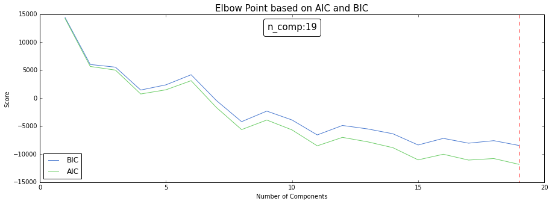

```python
#https://medium.com/sfu-cspmp/distilling-gaussian-mixture-models-701fa9546d9

from matplotlib.offsetbox import AnchoredText
%run edafunc.py

N = np.arange(1,20)
models = [GaussianMixture(n,covariance_type='full',random_state=random_state).fit(X_feat) for n in N]
elbow_point= min(np.argmin([m.bic(X_feat) for m in models]),np.argmin([m.bic(X_feat) for m in models]))+1

fig,ax = plt.subplots(1,1,figsize=(15,5))
plt.plot(N, [m.bic(X_feat) for m in models], label='BIC')
plt.plot(N, [m.aic(X_feat) for m in models], label='AIC')
plt.axvline(x=elbow_point,ymin=1,ymax=0,linestyle='--',color='red')
plt.legend(loc='lower left')
plt.xlabel('Number of Components')
plt.ylabel('Score')
plt.title(f"Elbow Point based on AIC and BIC",fontsize=15);
at = AnchoredText(f"n_comp:{elbow_point}",prop=dict(size=15), frameon=True,loc='upper center')
at.patch.set_boxstyle("round,pad=0.,rounding_size=0.2")
ax.add_artist(at);
```

#### Observations:

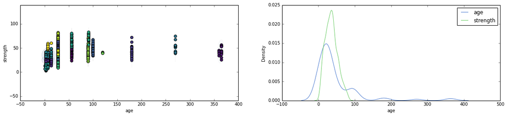

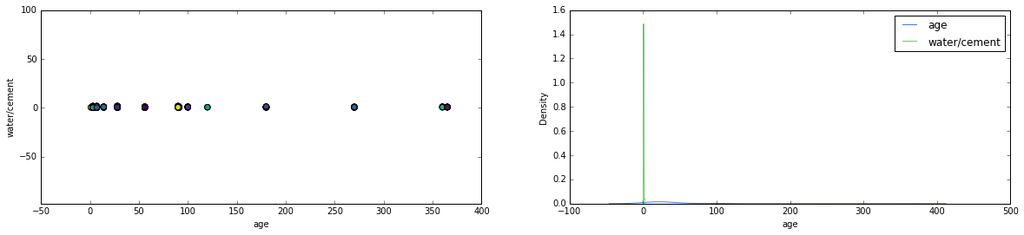

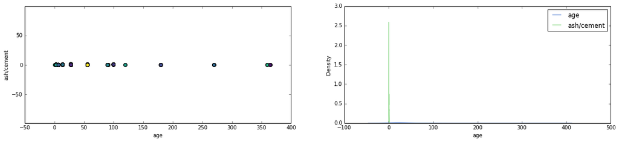

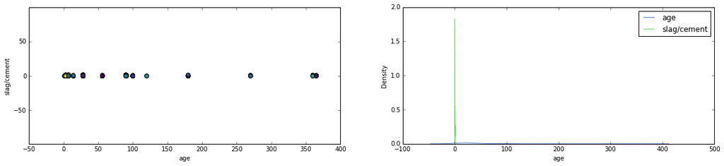

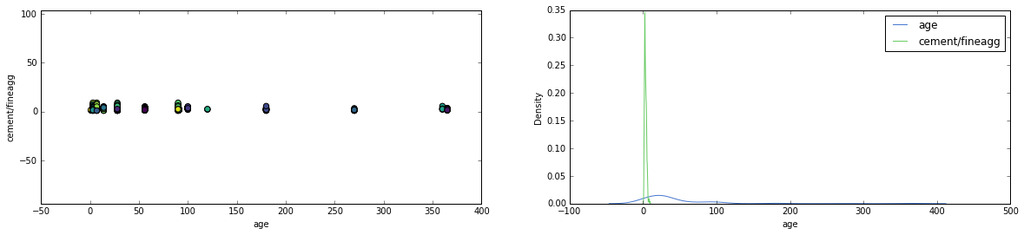

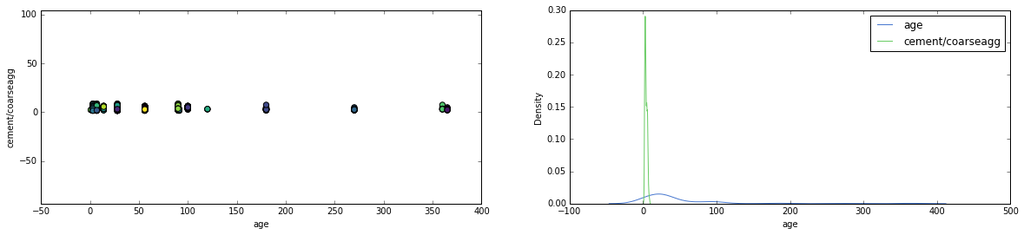

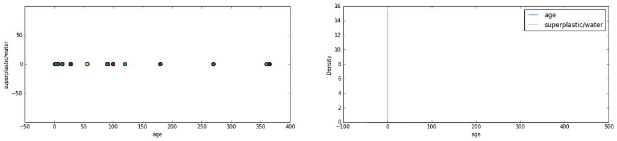

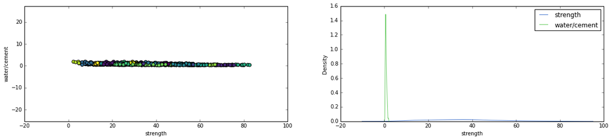

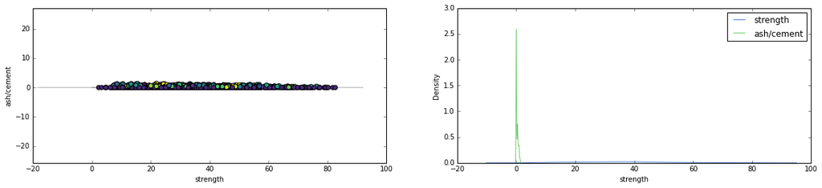

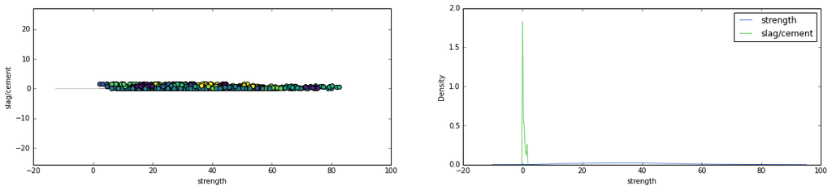

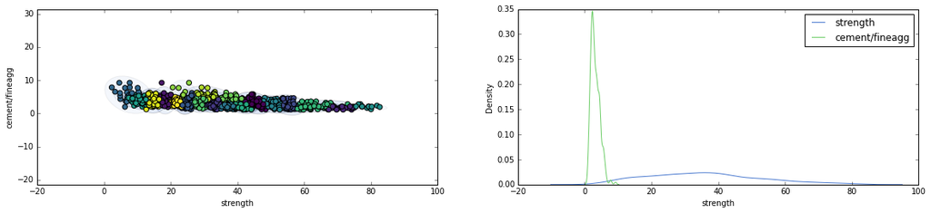

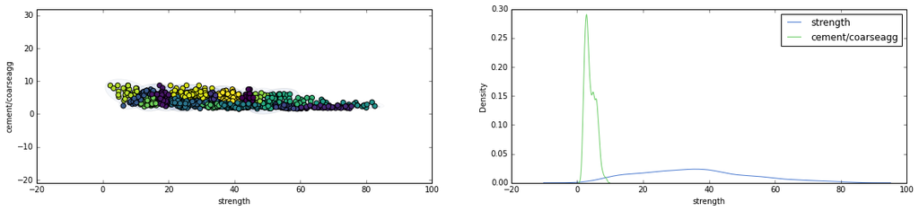

[16 more figures not shown]

```python
n_components = elbow_point
plt.rcParams["figure.figsize"] = (20,4)
gmm = GaussianMixture(n_components=n_components,covariance_type='full',random_state=random_state)
for feat_pairs in itertools.combinations(df_feat.columns,2):
    fig,ax = plt.subplots(1,2)
    plot_gmm(gmm,df_feat.loc[:,feat_pairs],ax=ax[0])
    sns.kdeplot(df_feat[feat_pairs[0]],ax=ax[1])
    sns.kdeplot(df_feat[feat_pairs[1]],ax=ax[1])
    plt.legend(list(feat_pairs))
    plt.show()
```

```python
gmm.fit(df_feat)
probs = gmm.predict_proba(df_feat)
labels = gmm.fit_predict(df_feat)
df_feat['Labels'] = labels
df_feat.sample(5)
```

|  | age | strength | water/cement | ash/cement | slag/cement | cement/fineagg | cement/coarseagg | superplastic/water | Labels |
| --- | --- | --- | --- | --- | --- | --- | --- | --- | --- |
| 374 | 28 | 25.97 | 0.689531 | 0.000000 | 0.000000 | 3.090253 | 3.494585 | 0.000000 | 16 |
| 603 | 7 | 21.82 | 0.881348 | 0.000000 | 1.500237 | 3.271476 | 4.636925 | 0.000000 | 9 |
| 470 | 3 | 12.45 | 0.850539 | 0.516179 | 0.000000 | 4.652799 | 5.168978 | 0.045290 | 2 |
| 21 | 7 | 21.92 | 0.814474 | 0.000000 | 1.500439 | 2.957456 | 4.192105 | 0.000000 | 9 |
| 125 | 28 | 31.03 | 1.473684 | 0.000000 | 1.578947 | 5.977444 | 7.135338 | 0.015306 | 16 |

##### Seperating data for each clusters based on the strength

```python
strength_mean=[]
for n in np.sort(df_feat['Labels'].unique()):
    display(f"Cluster - {n}")
    display(df_feat[df_feat['Labels'] == n].mean().to_frame().T)
    strength_mean.append(round(df_feat[df_feat['Labels'] == n]['strength'].mean(),3))
high_strength = np.argmax(strength_mean)
low_strength = np.argmin(strength_mean)
```

```
'Cluster - 0'
```

|  | age | strength | water/cement | ash/cement | slag/cement | cement/fineagg | cement/coarseagg | superplastic/water | Labels |
| --- | --- | --- | --- | --- | --- | --- | --- | --- | --- |
| 0 | 56.0 | 42.945273 | 0.787402 | 0.556109 | 0.113962 | 3.742753 | 4.739504 | 0.046597 | 0.0 |

```
'Cluster - 1'
```

|  | age | strength | water/cement | ash/cement | slag/cement | cement/fineagg | cement/coarseagg | superplastic/water | Labels |
| --- | --- | --- | --- | --- | --- | --- | --- | --- | --- |
| 0 | 363.5 | 42.6995 | 0.746059 | 0.0 | 0.287302 | 2.656458 | 3.445036 | 0.0 | 1.0 |

```
'Cluster - 2'
```

|  | age | strength | water/cement | ash/cement | slag/cement | cement/fineagg | cement/coarseagg | superplastic/water | Labels |
| --- | --- | --- | --- | --- | --- | --- | --- | --- | --- |
| 0 | 3.145455 | 16.169455 | 0.796481 | 0.577827 | 0.115912 | 3.789005 | 4.779075 | 0.047306 | 2.0 |

```
'Cluster - 3'
```

|  | age | strength | water/cement | ash/cement | slag/cement | cement/fineagg | cement/coarseagg | superplastic/water | Labels |
| --- | --- | --- | --- | --- | --- | --- | --- | --- | --- |
| 0 | 180.0 | 36.033889 | 0.707222 | 0.0 | 0.219797 | 2.697885 | 3.4045 | 0.0 | 3.0 |

```
'Cluster - 4'
```

|  | age | strength | water/cement | ash/cement | slag/cement | cement/fineagg | cement/coarseagg | superplastic/water | Labels |
| --- | --- | --- | --- | --- | --- | --- | --- | --- | --- |
| 0 | 28.0 | 54.717059 | 0.401703 | 0.273182 | 0.049187 | 1.898807 | 2.280518 | 0.072851 | 4.0 |

```
'Cluster - 5'
```

|  | age | strength | water/cement | ash/cement | slag/cement | cement/fineagg | cement/coarseagg | superplastic/water | Labels |
| --- | --- | --- | --- | --- | --- | --- | --- | --- | --- |
| 0 | 99.470588 | 53.764118 | 0.829868 | 0.626111 | 0.330971 | 3.793108 | 5.136029 | 0.055433 | 5.0 |

```
'Cluster - 6'
```

|  | age | strength | water/cement | ash/cement | slag/cement | cement/fineagg | cement/coarseagg | superplastic/water | Labels |
| --- | --- | --- | --- | --- | --- | --- | --- | --- | --- |
| 0 | 28.0 | 31.4648 | 1.156905 | 0.84966 | 0.798945 | 4.641098 | 5.857099 | 0.047123 | 6.0 |

```
'Cluster - 7'
```

|  | age | strength | water/cement | ash/cement | slag/cement | cement/fineagg | cement/coarseagg | superplastic/water | Labels |
| --- | --- | --- | --- | --- | --- | --- | --- | --- | --- |
| 0 | 270.0 | 51.272308 | 0.647171 | 0.0 | 0.275336 | 1.845443 | 2.803912 | 0.0 | 7.0 |

```
'Cluster - 8'
```

|  | age | strength | water/cement | ash/cement | slag/cement | cement/fineagg | cement/coarseagg | superplastic/water | Labels |
| --- | --- | --- | --- | --- | --- | --- | --- | --- | --- |
| 0 | 28.0 | 38.756842 | 0.672025 | 0.380344 | 0.16219 | 2.813817 | 3.398481 | 0.049941 | 8.0 |

```
'Cluster - 9'
```

|  | age | strength | water/cement | ash/cement | slag/cement | cement/fineagg | cement/coarseagg | superplastic/water | Labels |
| --- | --- | --- | --- | --- | --- | --- | --- | --- | --- |
| 0 | 5.567164 | 15.996493 | 0.815315 | 0.0 | 0.484083 | 3.305702 | 4.168276 | 0.0 | 9.0 |

```
'Cluster - 10'
```

|  | age | strength | water/cement | ash/cement | slag/cement | cement/fineagg | cement/coarseagg | superplastic/water | Labels |
| --- | --- | --- | --- | --- | --- | --- | --- | --- | --- |
| 0 | 5.027397 | 38.519863 | 0.407869 | 0.086829 | 0.284479 | 1.970015 | 2.334069 | 0.082125 | 10.0 |

```
'Cluster - 11'
```

|  | age | strength | water/cement | ash/cement | slag/cement | cement/fineagg | cement/coarseagg | superplastic/water | Labels |
| --- | --- | --- | --- | --- | --- | --- | --- | --- | --- |
| 0 | 56.0 | 65.556111 | 0.41084 | 0.092955 | 0.289925 | 1.986349 | 2.343037 | 0.085031 | 11.0 |

```
'Cluster - 12'
```

|  | age | strength | water/cement | ash/cement | slag/cement | cement/fineagg | cement/coarseagg | superplastic/water | Labels |
| --- | --- | --- | --- | --- | --- | --- | --- | --- | --- |
| 0 | 101.714286 | 42.798857 | 0.763956 | 0.491091 | 0.009414 | 3.661834 | 4.519039 | 0.038914 | 12.0 |

```
'Cluster - 13'
```

|  | age | strength | water/cement | ash/cement | slag/cement | cement/fineagg | cement/coarseagg | superplastic/water | Labels |
| --- | --- | --- | --- | --- | --- | --- | --- | --- | --- |
| 0 | 28.0 | 14.612121 | 1.270608 | 0.954839 | 0.183499 | 5.588396 | 6.467568 | 0.059746 | 13.0 |

```
'Cluster - 14'
```

|  | age | strength | water/cement | ash/cement | slag/cement | cement/fineagg | cement/coarseagg | superplastic/water | Labels |
| --- | --- | --- | --- | --- | --- | --- | --- | --- | --- |
| 0 | 90.0 | 40.48037 | 0.842769 | 0.0 | 0.495278 | 3.288397 | 4.035806 | 0.0 | 14.0 |

```
'Cluster - 15'
```

|  | age | strength | water/cement | ash/cement | slag/cement | cement/fineagg | cement/coarseagg | superplastic/water | Labels |
| --- | --- | --- | --- | --- | --- | --- | --- | --- | --- |
| 0 | 92.44 | 68.8624 | 0.44087 | 0.062375 | 0.363299 | 2.294668 | 2.682688 | 0.096498 | 15.0 |

```
'Cluster - 16'
```

|  | age | strength | water/cement | ash/cement | slag/cement | cement/fineagg | cement/coarseagg | superplastic/water | Labels |
| --- | --- | --- | --- | --- | --- | --- | --- | --- | --- |
| 0 | 28.0 | 39.824439 | 0.708305 | 0.0 | 0.507224 | 2.939969 | 3.755684 | 0.027231 | 16.0 |

```
'Cluster - 17'
```

|  | age | strength | water/cement | ash/cement | slag/cement | cement/fineagg | cement/coarseagg | superplastic/water | Labels |
| --- | --- | --- | --- | --- | --- | --- | --- | --- | --- |
| 0 | 180.0 | 54.5475 | 0.644272 | 0.0 | 0.22371 | 1.937511 | 2.891098 | 0.0 | 17.0 |

```
'Cluster - 18'
```

|  | age | strength | water/cement | ash/cement | slag/cement | cement/fineagg | cement/coarseagg | superplastic/water | Labels |
| --- | --- | --- | --- | --- | --- | --- | --- | --- | --- |
| 0 | 14.0 | 28.750968 | 0.751868 | 0.474056 | 0.099365 | 3.530809 | 4.495671 | 0.040708 | 18.0 |